# DESeq2 Notebook

## set-up

```r
# load data
library("pasilla")
# load package
library("DESeq2")
```

### load the count matrix file

To use `DESeqDataSetFromMatrix`, the user should provide the counts matrix, the information about the samples (the columns of the count matrix) as a DataFrame or data.frame, and the design formula.

```r
pasCts <- system.file("extdata",
                      "pasilla_gene_counts.tsv",
                      package="pasilla", mustWork=TRUE)
pasAnno <- system.file("extdata",
                       "pasilla_sample_annotation.csv",
                       package="pasilla", mustWork=TRUE)
cts <- as.matrix(read.csv(pasCts,sep="\t",row.names="gene_id"))
coldata <- read.csv(pasAnno, row.names=1)
coldata <- coldata[,c("condition","type")]
coldata$condition <- factor(coldata$condition)
coldata$type <- factor(coldata$type)
```

- `cts`: count matrix
- `coldtate`: The design matrix: The design formula should have all of the factors in your metadata that account for major sources of variation in your data. The last factor entered in the formula should be the condition of interest. `design <- ~ type + condiction`

It is absolutely critical that the columns of the count matrix and the rows of the column data (information about samples) are in the same order. DESeq2 will not make guesses as to which column of the count matrix belongs to which row of the column data, these must be provided to DESeq2 already in consistent order.

we need to re-arrange one or the other so that they are consistent in terms of sample order

```r
rownames(coldata) <- sub("fb", "", rownames(coldata))
all(rownames(coldata) %in% colnames(cts))
```

```
[1] TRUE
```

```r
all(rownames(coldata) == colnames(cts))
```

```
[1] FALSE
```

```r
cts <- cts[, rownames(coldata)]
all(rownames(coldata) == colnames(cts))
```

```
[1] TRUE
```

## proprocessing data

```r
dds <- DESeqDataSetFromMatrix(countData = cts,
                              colData = coldata,
                              design = ~ condition)
dds
```

```
class: DESeqDataSet
dim: 14599 7
metadata(1): version
assays(1): counts
rownames(14599): FBgn0000003 FBgn0000008 ... FBgn0261574 FBgn0261575
rowData names(0):
colnames(7): treated1 treated2 ... untreated3 untreated4
colData names(2): condition type
```

### filtering data

```r
keep <- rowSums(counts(dds)) >= 10
dds <- dds[keep,]
```

### justify reference level

Similar to Limma-voom method, R will choose a reference level for factors based on alphabetical order by default. There are two solutions: 1. you can either explicitly tell results which comparison to make using the contrast argument (as shown Limma-voom file), 2. you can explicitly set the factors levels. In order to see the change of reference levels reflected in the results names, you need to either run `DESeq` or `nbinomWaldTest`/`nbinomLRT` after the re-leveling operation. Setting the factor levels can be done in two ways, either using factor:

```r
dds$condition <- factor(dds$condition, levels = c("untreated","treated"))
```

or

```r
dds$condition <- relevel(dds$condition, ref = "untreated")
```

## DGE

```r
## Run analysis
dds_result <- DESeq(dds)
res <- results(dds_result)
res
```

```
log2 fold change (MLE): condition treated vs untreated
Wald test p-value: condition treated vs untreated
DataFrame with 9921 rows and 6 columns
              baseMean log2FoldChange     lfcSE       stat    pvalue      padj
             <numeric>      <numeric> <numeric>  <numeric> <numeric> <numeric>
FBgn0000008   95.14429     0.00227644  0.223729   0.010175 0.9918817  0.997211
FBgn0000014    1.05652    -0.49512039  2.143186  -0.231021 0.8172987        NA
FBgn0000017 4352.55357    -0.23991894  0.126337  -1.899041 0.0575591  0.288002
FBgn0000018  418.61048    -0.10467391  0.148489  -0.704927 0.4808558  0.826834
FBgn0000024    6.40620     0.21084779  0.689588   0.305759 0.7597879  0.943501
...                ...            ...       ...        ...       ...       ...
FBgn0261570 3208.38861      0.2955329  0.127350  2.3206264  0.020307  0.144240
FBgn0261572    6.19719     -0.9588230  0.775315 -1.2366888  0.216203  0.607848
FBgn0261573 2240.97951      0.0127194  0.113300  0.1122634  0.910615  0.982657
FBgn0261574 4857.68037      0.0153924  0.192567  0.0799327  0.936291  0.988179
FBgn0261575   10.68252      0.1635705  0.930911  0.1757102  0.860522  0.967928
```

The log fold change reflects the results of treated vs untreated.

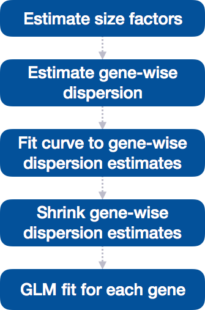

### Step 1: Estimate size factors

This step is to achieve the normalization. To normalize the count data, DESeq2 calculates size factors for each sample using the median of ratios.

```r
dds <- estimateSizeFactors(dds)
sizeFactors(dds)
```

```
  treated1   treated2   treated3 untreated1 untreated2 untreated3 untreated4
 1.6355014  0.7612159  0.8326603  1.1383376  1.7935406  0.6494828  0.7516005
```

### Step 2: Estimate gene-wise dispersion

DESeq2 assumes that genes with similar expression levels have similar dispersion. Thus, DESeq2 shares information across genes to generate more accurate estimates of variation based on the mean expression level of the gene.

### Step 3: Fit curve to gene-wise dispersion estimates

```r
dds <- estimateDispersions(dds)
```

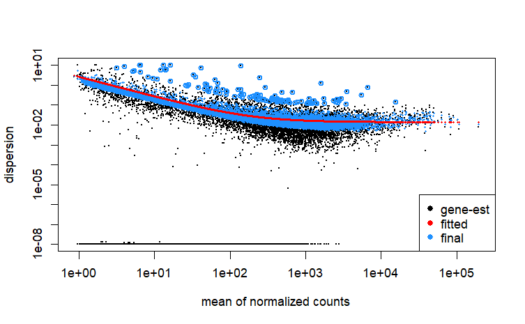

```r
plotDispEsts(dds)
```

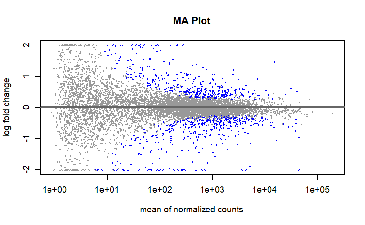

```r
# Generate the results table
res <- results(dds_result)

# Create the MA plot using DESeq2's 'plotMA' function
plotMA(res, main="MA Plot", ylim=c(-2, 2))
```

Here we demonstate the Log fold change shrinkage for visualization and ranking The estimation of fold changes can be affected by various factors, such as low counts, high variability, or small sample sizes. This can result in noisy or unstable fold change estimates, particularly for lowly expressed genes. Log fold change shrinkage aims to address these issues by borrowing information across all genes to adjust individual fold change estimates.

```r
resLFC <- lfcShrink(dds_result, coef="condition_treated_vs_untreated", type="apeglm")
```

```
using 'apeglm' for LFC shrinkage. If used in published research, please cite:
    Zhu, A., Ibrahim, J.G., Love, M.I. (2018) Heavy-tailed prior distributions for
    sequence count data: removing the noise and preserving large differences.
    Bioinformatics. https://doi.org/10.1093/bioinformatics/bty895
```

```r
resLFC
```

```
log2 fold change (MAP): condition treated vs untreated
Wald test p-value: condition treated vs untreated
DataFrame with 9921 rows and 5 columns
              baseMean log2FoldChange     lfcSE    pvalue      padj
             <numeric>      <numeric> <numeric> <numeric> <numeric>
FBgn0000008   95.14429     0.00119920  0.151897 0.9918817  0.997211
FBgn0000014    1.05652    -0.00473412  0.205468 0.8172987        NA
FBgn0000017 4352.55357    -0.18989990  0.120377 0.0575591  0.288002
FBgn0000018  418.61048    -0.06995753  0.123901 0.4808558  0.826834
FBgn0000024    6.40620     0.01752715  0.198633 0.7597879  0.943501
...                ...            ...       ...       ...       ...
FBgn0261570 3208.38861     0.24110290 0.1244469  0.020307  0.144240
FBgn0261572    6.19719    -0.06576173 0.2141351  0.216203  0.607848
FBgn0261573 2240.97951     0.01000619 0.0993764  0.910615  0.982657
FBgn0261574 4857.68037     0.00843552 0.1408267  0.936291  0.988179
FBgn0261575   10.68252     0.00809101 0.2014704  0.860522  0.967928
```

he options for type are:

- `apeglm` is the adaptive t prior shrinkage estimator from the `apeglm` package (Zhu, Ibrahim, and Love 2018).
- `ashr` is the adaptive shrinkage estimator from the `ashr` package (Stephens 2016). Here DESeq2 uses the `ashr` option to fit a mixture of Normal distributions to form the prior, with method=“shrinkage”.
- `normal` is the the original DESeq2 shrinkage estimator, an adaptive Normal distribution as prior.

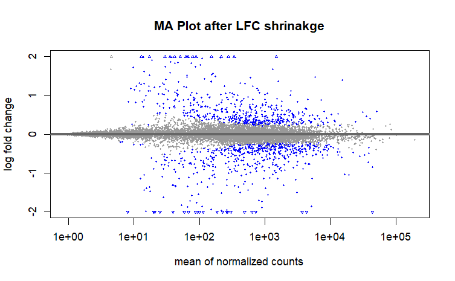

```r
# plot of MA after shrinkage
plotMA(resLFC, main="MA Plot after LFC shrinakge", ylim=c(-2, 2))
```

The results are so much better, especially for low expression counts.

#### comparing the results of three shrink methods

```r
# because we are interested in treated vs untreated, we set 'coef=2'
resNorm <- lfcShrink(dds_result, coef=2, type="normal")
```

```
using 'normal' for LFC shrinkage, the Normal prior from Love et al (2014).

Note that type='apeglm' and type='ashr' have shown to have less bias than type='normal'.
See ?lfcShrink for more details on shrinkage type, and the DESeq2 vignette.
Reference: https://doi.org/10.1093/bioinformatics/bty895
```

```r
resAsh <- lfcShrink(dds_result, coef=2, type="ashr")
```

```
using 'ashr' for LFC shrinkage. If used in published research, please cite:
    Stephens, M. (2016) False discovery rates: a new deal. Biostatistics, 18:2.
    https://doi.org/10.1093/biostatistics/kxw041
```

```r
par(mfrow=c(1,3), mar=c(4,4,2,1))
xlim <- c(1,1e5); ylim <- c(-3,3)
plotMA(resLFC, xlim=xlim, ylim=ylim, main="apeglm")
plotMA(resNorm, xlim=xlim, ylim=ylim, main="normal")
```

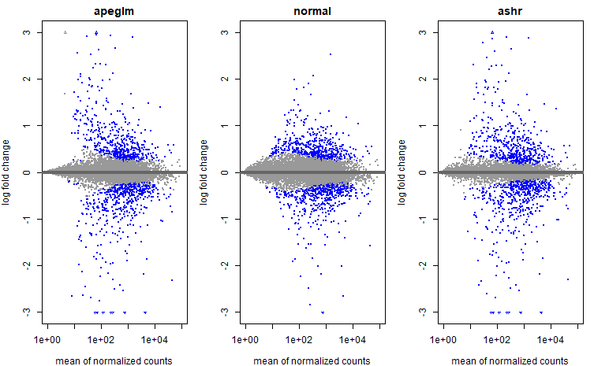

```r
plotMA(resAsh, xlim=xlim, ylim=ylim, main="ashr")
```

### calculate p-value

the results function automatically performs independent filtering based on the mean of normalized counts for each gene, optimizing the number of genes which will have an adjusted p value below a given FDR cutoff, alpha.

```r
res05 <- results(dds_result, alpha=0.05)
summary(res05)
```

```
out of 9921 with nonzero total read count
adjusted p-value < 0.05
LFC > 0 (up)       : 407, 4.1%
LFC < 0 (down)     : 431, 4.3%
outliers [1]       : 1, 0.01%
low counts [2]     : 1347, 14%
(mean count < 5)
[1] see 'cooksCutoff' argument of ?results
[2] see 'independentFiltering' argument of ?results
```

# reference

- https://bioconductor.org/packages/release/bioc/vignettes/DESeq2/inst/doc/DESeq2.html#altshrink
- https://bioconductor.org/packages/release/workflows/vignettes/rnaseqGene/inst/doc/rnaseqGene.html
- https://hbctraining.github.io/DGE_workshop/lessons/04_DGE_DESeq2_analysis.html